# Swire Coca-Cola USA (SCCU) - Group Modeling Notebook

> Swire Coca-Cola USA (SCCU) - Group Modeling Notebook

> > Introduction

> > Main questions

> > Requirement

> > Thing to consider in modeling

> > Business Problem

> > Analytical Approach

> > Import Packages

> > Load Dataset

> > Pipeline Class of Routing Optimizer

> > Sequences of Pipeline

> > Customer Segmentation based on the transition status

> > > Create Transition Status Variable

> > > Dataset Cleaning

> > > Iteratively Building Decision Trees

> > > > SMOTE

> > > > Undersampling

> > > XGBoost Model

> > > > Grid Search and Model Training

> > > > Generate Predictions on Train and Test Set

> > > > Feature Importance

> > Delivery Cost Optimization

> > Logistic Regression Model Training

> > Number of Customers who Improved from Below to Above

> > Cluster Improved Customers by ZIP Code and Volume

> > Cluster Improved Customers data using Ordered Gallon

> > Ordered cases and Gallons Comparison

> > Multi-Dimensional Clustering

> > Average Delivery Cost Per Case

> > Before Vs After Clustering -Comparing Cost per Delivery

> > Percentage Cost Savings

> > Average Cost per Gallon Before Clustering

> > Average cost per Gallon After Clustering

> > Visuals for Average Cost per Case Before vs After Clustering

> > Visuals for cost per Gallon Before vs After Clustering

> > > Annual Delivery Cost Statistics

> > > Modelling: Predicting potential growth-ready customers

> > > > Prepare the Data

> > > Benchmark Model: Logistic Regression

> > > Random Forest Model

> > > GridSearchCV with Random Forest Classifier

> > > GradientBoosting(Using XGBoost) with GridSearch

> > > > Characteristics of customer growth

> > > Group1: Sensitivity Analysis

> > > Group2: Analysis on Local Market Partners who only buy Fountain

> > Result

> > Group Member Contribution

## Introduction

This notebook includes the pipeline to predict the growth potential customer & the decision modeling to find the optimized threshold with Machine Learning framework.

## Main questions

- (Richard Lim) What factors or characteristics distinguish customers with annual sales exceeding the determined volume threshold from those below this threshold?
- 2023 (Below vs Above): figure out factors differing between above vs below group
- 2024 (Below vs Above): figure out factors differing between above vs below group
- (Varun Selvam) How can SCCU uses historical sales data, or other Customer Characteristics to predict which ARTM customers have the potential to grow beyond the volume threshold annually?
- Which customer characteristics contribute to move customers from below threshold (2023) to above threshold (2024)?
- (Meenakshi H) How can these insights be integrated into the routing strategy to support long-term growth while maintaining logistical efficiency?
- logistical efficiency represents how much we can save delivery cost at maximum while increasing the number of growth customer (Below to Above Group)
- (Nikita Muddapati) What levers can be employed to accelerate volume and share growth at growth-ready, high-potential customers?
- Business Recommendation: accurate number + storytelling to take action
- Question: which threshold should be used for new logistical efficiency?
- Reason: Reasoning why the threshold is better than original one (400 annual threshold)

## Requirement

- A statement of the business and analytic problems for the project.
- Documentation of your modeling process (as well as any additional data cleaning and preparation you did) along with an interpretation of your results. This writing belongs in the main sections of the notebook dedicated to the modeling process, and should go between code chunks.
- Code annotation. This writing goes within code chunks, and should explain what the code is doing.
- All the performance metrics for the best model: in-sample and estimated out-of-sample performance.
- A results section at the end where you summarize the key points of what you have learned through the group modeling process. Can modeling results be used to solve the business problem?

## Thing to consider in modeling

- Identify a performance benchmark. What is a minimum threshold for model performance?
- Identify appropriate models to explore (given the business problem and the project objective).
- Do additional data preparation and feature engineering as necessary. Perform cross-validation to develop performance metrics for each model, appropriate for the context.
- Optimize model performance with hyperparameter tuning, if appropriate.
- Evaluate the strengths and weaknesses of each model and select the best one.
- Perform business validation of the model. Are your results sufficient to solve the business problem?

## Business Problem

SCCU(Swire Coca-Cola United States) tries to optimize logistics by transitioning customers selling below a specific annual volume to an Alternate Route to Market (ARTM). There is an annual 400 gallons volume threshold used to distinguish the customers between the direct delivery route and ARTM.

However, SCCU is looking for a more cost-efficient strategy to decide new threshold for optimizing logistics which is driving better operational efficiency and more revenues.

## Analytical Approach

This analysis will focus on building the classification model to predict who is going to be a growth customer segment (those who were below the threshold from 2023 but becoming above the threshold on following year (2024)) based on the 2023 historical data only, and which volume threshold would be more optimal compared to original threshold.

## Import Packages

```python
# import libraries

import pandas as pd
import numpy as np
import matplotlib.pyplot as plt
import seaborn as sns

from sklearn.model_selection import train_test_split, GridSearchCV, StratifiedKFold
from sklearn.preprocessing import StandardScaler, OneHotEncoder
from sklearn.compose import ColumnTransformer
from sklearn.pipeline import Pipeline
from sklearn.impute import SimpleImputer
from sklearn.preprocessing import FunctionTransformer
from sklearn.tree import DecisionTreeClassifier
from imblearn.over_sampling import SMOTE

from sklearn.ensemble import RandomForestClassifier, GradientBoostingClassifier
from sklearn.linear_model import LogisticRegression
from xgboost import XGBClassifier

from sklearn.metrics import classification_report, confusion_matrix, roc_auc_score, precision_recall_curve
from sklearn.metrics import accuracy_score, f1_score, precision_score, recall_score, roc_auc_score
from collections import Counter
from sklearn.utils import resample
from sklearn.linear_model import LogisticRegression


# Machine Learning
from sklearn.model_selection import train_test_split
from sklearn.preprocessing import StandardScaler
from sklearn.linear_model import LogisticRegression, Ridge, Lasso
from sklearn.ensemble import RandomForestRegressor
#from sklearn.metrics import mean_absolute_error, mean_squared_error, r2_score

import xgboost as xgb

from sklearn.ensemble import RandomForestClassifier
from sklearn.model_selection import GridSearchCV
from sklearn.model_selection import train_test_split


# to impute NA's
from sklearn.pipeline import Pipeline
from sklearn.impute import SimpleImputer

from sklearn.metrics import classification_report, confusion_matrix,accuracy_score,roc_auc_score, roc_curve


# DV
import matplotlib.pyplot as plt
import seaborn as sns

# Statistical Analysis
#!pip install statsmodels
import scipy.stats as stats

# Warnings
import warnings
warnings.filterwarnings("ignore")

import pickle
import joblib
import warnings

warnings.filterwarnings('ignore')

# Set plotting style
plt.style.use('seaborn-v0_8-whitegrid')
sns.set_palette('viridis')
```

## Load Dataset

```python
# Load data
file_path = pd.read_csv('sccu_data.csv')
```

## Pipeline Class of Routing Optimizer

This code includes all of the pipeline that implement the prediction modeling of growth potential customer (Below in 2023, Above in 2024) based on the only 2023 historical data, and redefining the threshold for optimizing the SCCU logistical routes.

```python
class SCCURoutingOptimizer:
    """
    ML pipeline for SCCU route optimization:
    1. Predicts growth potential for ARTM customers
    2. Identifies optimal thresholds for routing decisions
    3. Provides actionable business insights
    """

    def __init__(self, data_path='sccu_data.csv'):
        """Initialize with path to data file"""
        self.data_path = data_path
        self.data = None
        self.X_train = None
        self.X_test = None
        self.y_train = None
        self.y_test = None
        self.models = {}
        self.best_model = None

    # Define the lambda function inside the method
    @staticmethod
    def bool_to_int_func(x):
        return x.astype(int)

    def load_data(self):
        """Load and perform initial data processing"""
        print("1. Loading and preprocessing data")

        # Load data
        self.data = pd.read_csv(self.data_path)

        # Basic info
        print(f"Dataset shape: {self.data.shape}")
        print(f"Missing values:\n{self.data[self.data.columns[self.data.isnull().sum() > 0]].isnull().sum()}")

        # Analyze current thresholds
        print("\n3.Analyzing current thresholds...")
        self.analyze_current_thresholds()

        return self.data

    def create_derived_features(self):
        """Create additional features for analysis and prediction"""

        # Target variable for growth prediction: Did customer move from below to above threshold?
        self.data['GROWTH_TARGET'] = ((self.data['THRESHOLD_2023'] == 'below') &
                                    (self.data['THRESHOLD_2024'] == 'above')).astype(int)

        # Print derived features
        print(f"Added derived 1 variables. New shapes are: {self.data.shape}")

    def analyze_current_thresholds(self, number = 400):
        """Analyze the current threshold strategy effectiveness"""

        # Calculate additional derived features
        print("\n2.Creating derived features...")
        self.create_derived_features()

        # Current distribution
        print(f"\n{number} Annual Threshold distribution:")
        below_threshold_2023 = (self.data['THRESHOLD_2023'] == 'below').sum()
        above_threshold_2023 = (self.data['THRESHOLD_2023'] == 'above').sum()
        below_threshold_2024 = (self.data['THRESHOLD_2024'] == 'below').sum()
        above_threshold_2024 = (self.data['THRESHOLD_2024'] == 'above').sum()

        # The number of Customer Movement between thresholds
        below_to_above = ((self.data['THRESHOLD_2023'] == 'below') &
                          (self.data['THRESHOLD_2024'] == 'above')).sum()
        above_to_below = ((self.data['THRESHOLD_2023'] == 'above') &
                          (self.data['THRESHOLD_2024'] == 'below')).sum()
        below_to_below = ((self.data['THRESHOLD_2023'] == 'below') &
                          (self.data['THRESHOLD_2024'] == 'below')).sum()
        above_to_above = ((self.data['THRESHOLD_2023'] == 'above') &
                          (self.data['THRESHOLD_2024'] == 'above')).sum()
        entire = below_to_above + above_to_below + below_to_below + above_to_above

        # Comparison for customers who changed categories
        growth_customers = self.data[self.data['GROWTH_TARGET'] == 1]
        decline_customers = self.data[((self.data['THRESHOLD_2023'] == 'above') &
                                      (self.data['THRESHOLD_2024'] == 'below'))]
        same_above_customer = self.data[(self.data['THRESHOLD_2023'] == 'above') &
                                                    (self.data['THRESHOLD_2024'] == 'above')]
        same_below_customer= self.data[(self.data['THRESHOLD_2023'] == 'below') &
                                                    (self.data['THRESHOLD_2024'] == 'below')]

        print("----------------------------------------------------------")
        print(f"2023: Below threshold: {below_threshold_2023} ({below_threshold_2023/len(self.data)*100:.2f}%), "
              f"Above threshold: {above_threshold_2023} ({above_threshold_2023/len(self.data)*100:.2f}%)")
        print(f"2024: Below threshold: {below_threshold_2024} ({below_threshold_2024/len(self.data)*100:.2f}%), "
              f"Above threshold: {above_threshold_2024} ({above_threshold_2024/len(self.data)*100:.2f}%)")
        print("----------------------------------------------------------")


        print("\nThe number of customer proportion between thresholds:")

        print("----------------------------------------------------------")
        print(f"Below to Above (Growth): {below_to_above} "
              f"({below_to_above/entire * 100:.2f}% of total)")
        print(f"Above to Below (Decline): {above_to_below} "
              f"({above_to_below/entire * 100:.2f}% of total)")
        print(f"Below to Below (No Change): {below_to_below} "
              f"({below_to_below/entire * 100:.2f}% of total)")
        print(f"Above to Above (No Change): {above_to_above} "
              f"({above_to_above/entire * 100:.2f}% of total)")
        print("----------------------------------------------------------")

        # Current threshold analysis
        print("\n3.Current threshold analysis:")

        print(f"\nIf {number} Annual Threshold were applied...")



        print("\n\nVolume Change")

        print("----------------------------------------------------------")

        print("\nTotal annumal volume change from 2023 to 2024")
        print(f"2023: {self.data['ANNUAL_VOLUME_2023'].sum():.2f} units")
        print(f"2024: {self.data['ANNUAL_VOLUME_2024'].sum():.2f} units")
        print(f"Change: {self.data['ANNUAL_VOLUME_2024'].sum() - self.data['ANNUAL_VOLUME_2023'].sum():.2f} units")

        print("----------------------------------------------------------")

        print("\nTotal annual volume change for no change (below to below):")
        print(f"2023: {same_below_customer['ANNUAL_VOLUME_2023'].sum():.2f} units")
        print(f"2024: {same_below_customer['ANNUAL_VOLUME_2024'].sum():.2f} units")
        print(f"Change: {same_below_customer['ANNUAL_VOLUME_2024'].sum() - same_below_customer['ANNUAL_VOLUME_2023'].sum():.2f} units")
```

```python
        print("\nTotal annual volume change for growth customers (below to above):")
        print(f"2023: {growth_customers['ANNUAL_VOLUME_2023'].sum():.2f} units")
        print(f"2024: {growth_customers['ANNUAL_VOLUME_2024'].sum():.2f} units")
        print(f"Change: {growth_customers['ANNUAL_VOLUME_2024'].sum() - growth_customers['ANNUAL_VOLUME_2023'].sum():.2f} units")

        print("\nTotal annual volume change for no change (above to above):")
        print(f"2023: {same_above_customer['ANNUAL_VOLUME_2023'].sum():.2f} units")
        print(f"2024: {same_above_customer['ANNUAL_VOLUME_2024'].sum():.2f} units")
        print(f"Change: {same_above_customer['ANNUAL_VOLUME_2024'].sum()- same_above_customer['ANNUAL_VOLUME_2023'].sum():.2f} units")

        print("\nTotal annual volume change for decline customers (above to below):")
        print(f"2023: {decline_customers['ANNUAL_VOLUME_2023'].sum():.2f} units")
        print(f"2024: {decline_customers['ANNUAL_VOLUME_2024'].sum():.2f} units")
        print(f"Change: {decline_customers['ANNUAL_VOLUME_2024'].sum() - decline_customers['ANNUAL_VOLUME_2023'].sum():.2f} units")

        print("----------------------------------------------------------")

        print("\n\nDelivery cost change")

        print("----------------------------------------------------------")

        print("\nTotal annumal delivery cost change from 2023 to 2024")
        print(f"2023: ${self.data['DELIVERY_COST_2023'].sum():.2f}")
        print(f"2024: ${self.data['DELIVERY_COST_2024'].sum():.2f}")
        print(f"Change: ${self.data['DELIVERY_COST_2024'].sum() - self.data['DELIVERY_COST_2023'].sum():.2f}")

        print("----------------------------------------------------------")

        print("\nTotal delivery cost change for no change (below to below):")
        print(f"2023: ${same_below_customer['DELIVERY_COST_2023'].sum():.2f}")
        print(f"2024: ${same_below_customer['DELIVERY_COST_2024'].sum():.2f}")
        print(f"Change: ${same_below_customer['DELIVERY_COST_2024'].sum() - same_below_customer['DELIVERY_COST_2023'].sum():.2f}")

        print("\nTotal delivery cost change for growth customers (below to above):")
        print(f"2023: ${growth_customers['DELIVERY_COST_2023'].sum():.2f}")
        print(f"2024: ${growth_customers['DELIVERY_COST_2024'].sum():.2f}")
        print(f"Change: ${growth_customers['DELIVERY_COST_2024'].sum() - growth_customers['DELIVERY_COST_2023'].sum():.2f}")

        print("\nTotal delivery cost change for no change (above to above):")
        print(f"2023: ${same_above_customer['DELIVERY_COST_2023'].sum():.2f}")
        print(f"2024: ${same_above_customer['DELIVERY_COST_2024'].sum():.2f}")
        print(f"Change: ${same_above_customer['DELIVERY_COST_2024'].sum() - same_above_customer['DELIVERY_COST_2023'].sum():.2f}")

        print("\nTotal delivery cost change for decline customers (above to below):")
        print(f"2023: ${decline_customers['DELIVERY_COST_2023'].sum():.2f}")
        print(f"2024: ${decline_customers['DELIVERY_COST_2024'].sum():.2f}")
        print(f"Change: ${decline_customers['DELIVERY_COST_2024'].sum() - decline_customers['DELIVERY_COST_2023'].sum():.2f}")

        print("----------------------------------------------------------")

    def explore_data(self):
        """Perform exploratory data analysis for insights"""

        print("\n4.Exploring data for insights...")

        # Growth customer analysis
        growth_df = self.data[self.data['GROWTH_TARGET'] == 1]
        print(f"\nAnalyzing {len(growth_df)} growth customers (moved from below to above threshold)")

        # Trade channel distribution for growth customers
        trade_channel_growth = growth_df['TRADE_CHANNEL'].value_counts().head(10)
        print("\nTop 10 trade channels for growth customers:")
        print(trade_channel_growth)

        # Calculate growth rate by trade channel
        channel_growth_rates = []
        for channel in self.data['TRADE_CHANNEL'].unique():
            channel_customers = self.data[self.data['TRADE_CHANNEL'] == channel]
            below_customers = channel_customers[channel_customers['THRESHOLD_2023'] == 'below']
            growth_customers = below_customers[below_customers['THRESHOLD_2024'] == 'above']

            if len(below_customers) > 0:
                growth_rate = len(growth_customers) / len(below_customers) * 100
                channel_growth_rates.append((channel, len(below_customers), len(growth_customers), growth_rate))

        # Sort by growth rate and show top channels
        channel_growth_df = pd.DataFrame(channel_growth_rates,
                                       columns=['Channel', 'Below Customers', 'Growth Customers', 'Growth Rate'])
        channel_growth_df = channel_growth_df.sort_values('Growth Rate', ascending=False)
        print("\nTop trade channels by growth rate (%):")
        print(channel_growth_df.head(10))

        # Cold drink channel analysis
        cold_drink_growth_rates = []
        for channel in self.data['COLD_DRINK_CHANNEL'].unique():
            channel_customers = self.data[self.data['COLD_DRINK_CHANNEL'] == channel]
            below_customers = channel_customers[channel_customers['THRESHOLD_2023'] == 'below']
            growth_customers = below_customers[below_customers['THRESHOLD_2024'] == 'above']

            if len(below_customers) > 0:
                growth_rate = len(growth_customers) / len(below_customers) * 100
                cold_drink_growth_rates.append((channel, len(below_customers), len(growth_customers), growth_rate))

        cold_drink_growth_df = pd.DataFrame(cold_drink_growth_rates,
                                          columns=['Channel', 'Below Customers', 'Growth Customers', 'Growth Rate'])
        cold_drink_growth_df = cold_drink_growth_df.sort_values('Growth Rate', ascending=False)
        print("\nCold drink channels by growth rate (%):")
        print(cold_drink_growth_df)

        # Partner status analysis
        partner_stats = self.data.groupby(['LOCAL_MARKET_PARTNER', 'THRESHOLD_2023']).size().unstack()
        partner_growth = self.data[self.data['THRESHOLD_2023'] == 'below'].groupby('LOCAL_MARKET_PARTNER')['GROWTH_TARGET'].mean() * 100
        print("\nGrowth rate by local market partner status (%):")
        print(partner_growth)
```

```python
        # CO2 customer analysis
        co2_stats = self.data.groupby(['CO2_CUSTOMER', 'THRESHOLD_2023']).size().unstack()
        co2_growth = self.data[self.data['THRESHOLD_2023'] == 'below'].groupby('CO2_CUSTOMER')['GROWTH_TARGET'].mean() * 100
        print("\nGrowth rate by CO2 customer status (%):")
        print(co2_growth)

        # Transaction count analysis
        self.data['TRANS_COUNT_BUCKET'] = pd.cut(
            self.data['TRANS_COUNT_2023'],
            bins=[0, 5, 10, 20, 30, np.inf],
            labels=['0-5', '5-10', '10-20', '20-30', '30+']
        )

        trans_growth = self.data[self.data['THRESHOLD_2023'] == 'below'].groupby('TRANS_COUNT_BUCKET')['GROWTH_TARGET'].agg(['size', 'sum', 'mean'])
        trans_growth['growth_rate'] = trans_growth['mean'] * 100
        print("\nGrowth rate by transaction count bucket (%):")
        print(trans_growth)

        # Average order volume analysis
        self.data['AVG_ORDER_BUCKET'] = pd.cut(
            self.data['AVG_ORDER_VOLUME_2023'],
            bins=[0, 10, 20, 30, 40, np.inf],
            labels=['0-10', '10-20', '20-30', '30-40', '40+']
        )

        order_growth = self.data[self.data['THRESHOLD_2023'] == 'below'].groupby('AVG_ORDER_BUCKET')['GROWTH_TARGET'].agg(['size', 'sum', 'mean'])
        order_growth['growth_rate'] = order_growth['mean'] * 100
        print("\nGrowth rate by average order volume bucket (%):")
        print(order_growth)

        return growth_df

    def _prepare_features_and_target(self):
        """Prepare features and target variable for modeling"""
        # Focus on customers below threshold in 2023
        below_threshold = self.data[self.data['THRESHOLD_2023'] == 'below'].copy()

        # Define features and target
        target = 'GROWTH_TARGET'

        # Numerical features
        numerical_features = [
            'TRANS_COUNT_2023',
            'ANNUAL_VOLUME_CASES_2023',
            'ANNUAL_VOLUME_GALLON_2023',
            'AVG_ORDER_VOLUME_2023',
            'DELIVERY_COST_2023_CASES',
            'DELIVERY_COST_2023_GALLON'
        ]

        # Categorical features
        categorical_features = [
            'STATE_SHORT',
            'TRADE_CHANNEL',
            'SUB_TRADE_CHANNEL',
            'COLD_DRINK_CHANNEL',
            'FREQUENT_ORDER_TYPE'
        ]

        # Boolean features
        boolean_features = [
            'LOCAL_MARKET_PARTNER',
            'CO2_CUSTOMER'
        ]

        # Feature lists
        feature_columns = numerical_features + categorical_features + boolean_features

        # Print feature information
        print(f"\nUsing {len(numerical_features)} numerical features, "
              f"{len(categorical_features)} categorical features, and "
              f"{len(boolean_features)} boolean features")

        # Create feature matrix and target vector
        X = below_threshold[feature_columns].copy()
        y = below_threshold[target].copy()

        # Check for missing values
        missing_values = X.isnull().sum()
        print("\nFeatures with missing values:")
        print(missing_values[missing_values > 0])

        return X, y

    def prepare_data_for_modeling(self, test_size=0.2, random_state=42):
        """Prepare training and test datasets for modeling"""

        print("\nPreparing data for modeling...")

        # Get features and target
        X, y = self._prepare_features_and_target()

        # Split data
        self.X_train, self.X_test, self.y_train, self.y_test = train_test_split(
            X, y, test_size=test_size, random_state=random_state, stratify=y
        )

        print(f"Training set: {len(self.X_train)} samples")
        print(f"Test set: {len(self.X_test)} samples")
        print(f"Positive class (growth) in train: {sum(self.y_train)} ({sum(self.y_train)/len(self.y_train)*100:.2f}%)")
        print(f"Positive class (growth) in test: {sum(self.y_test)} ({sum(self.y_test)/len(self.y_test)*100:.2f}%)")

        return self.X_train, self.X_test, self.y_train, self.y_test

    def create_preprocessing_pipeline(self):
        """Create a preprocessing pipeline for numerical and categorical features"""
        # Identify numerical and categorical columns
        numerical_columns = self.X_train.select_dtypes(include=['int64', 'float64']).columns.tolist()
        categorical_columns = self.X_train.select_dtypes(include=['object']).columns.tolist()
        boolean_columns = self.X_train.select_dtypes(include=['bool']).columns.tolist()

        # Create preprocessing steps
        numerical_transformer = Pipeline(steps=[
            ('imputer', SimpleImputer(strategy='median')),
            ('scaler', StandardScaler())
        ])

        categorical_transformer = Pipeline(steps=[
            ('imputer', SimpleImputer(strategy='most_frequent')),
            ('onehot', OneHotEncoder(handle_unknown='ignore'))
        ])

        boolean_transformer = Pipeline(steps=[
            ('bool_to_int', FunctionTransformer(self.bool_to_int_func)),  # Convert bool to int
            ('imputer', SimpleImputer(strategy='most_frequent'))
        ])

        # Create the column transformer
        preprocessor = ColumnTransformer(
            transformers=[
                ('num', numerical_transformer, numerical_columns),
                ('cat', categorical_transformer, categorical_columns),
                ('bool', boolean_transformer, boolean_columns)
            ],
            remainder='drop'
        )

        return preprocessor

    def train_models(self, use_smote=True):
        """Train multiple ML models to predict growth potential"""

        print("\nTraining models to predict growth potential...")

        # Create preprocessing pipeline
        preprocessor = self.create_preprocessing_pipeline()

        # Apply SMOTE to handle class imbalance if needed
        if use_smote:
            print("Applying SMOTE to handle class imbalance...")
            smote = SMOTE(random_state=42)
            X_train_processed = preprocessor.fit_transform(self.X_train)
            X_train_resampled, y_train_resampled = smote.fit_resample(X_train_processed, self.y_train)
            # print(f"After SMOTE - Training samples: {len(X_train_resampled)}, "
            #       f"Positive class: {sum(y_train_resampled)} ({sum(y_train_resampled)/len(y_train_resampled)*100:.2f}%)")
            print(f"After SMOTE - Training samples: {X_train_resampled.shape[0]}, "
                  f"Positive class: {np.sum(y_train_resampled)}({np.sum(y_train_resampled)/X_train_resampled.shape[0]*100:.2f}%)")
        else:
            X_train_resampled, y_train_resampled = self.X_train, self.y_train
```

```python
        # Define models to train
        models = {
            'logistic_regression': Pipeline([
                ('preprocessor', preprocessor),
                ('classifier', LogisticRegression(class_weight='balanced', max_iter=1000, random_state=42))
            ]),
            'random_forest': Pipeline([
                ('preprocessor', preprocessor),
                ('classifier', RandomForestClassifier(n_estimators=100, class_weight='balanced', random_state=42))
            ]),
            'gradient_boosting': Pipeline([
                ('preprocessor', preprocessor),
                ('classifier', GradientBoostingClassifier(n_estimators=100, random_state=42))
            ]),
            'xgboost': Pipeline([
                ('preprocessor', preprocessor),
                ('classifier', XGBClassifier(n_estimators=100, use_label_encoder=False, eval_metric='logloss', random_state=42))
            ])
        }

        # Train each model and store
        for name, model in models.items():
            print(f"\nTraining {name}...")
            if use_smote:
                # For SMOTE, fit preprocessor first, then classifier
                pipeline_model = model
                pipeline_model.fit(self.X_train, self.y_train)

                # Get the classifier from the pipeline
                classifier = pipeline_model.named_steps['classifier']

                # Replace the raw estimator with SMOTE-trained version
                if name == 'logistic_regression':
                    pipeline_model.named_steps['classifier'] = LogisticRegression(
                        class_weight='balanced', max_iter=1000, random_state=42
                    ).fit(X_train_resampled, y_train_resampled)
                elif name == 'random_forest':
                    pipeline_model.named_steps['classifier'] = RandomForestClassifier(
                        n_estimators=100, class_weight='balanced', random_state=42
                    ).fit(X_train_resampled, y_train_resampled)
                elif name == 'gradient_boosting':
                    pipeline_model.named_steps['classifier'] = GradientBoostingClassifier(
                        n_estimators=100, random_state=42
                    ).fit(X_train_resampled, y_train_resampled)
                elif name == 'xgboost':
                    pipeline_model.named_steps['classifier'] = XGBClassifier(
                        n_estimators=100, use_label_encoder=False, eval_metric='logloss', random_state=42
                    ).fit(X_train_resampled, y_train_resampled)

                self.models[name] = pipeline_model
            else:
                # Without SMOTE, fit the full pipeline
                model.fit(self.X_train, self.y_train)
                self.models[name] = model

        return self.models

    def evaluate_models(self):
        """Evaluate model performance on test data"""
        if not self.models:
            print("No trained models found. Call train_models() first.")
            return

        print("\nEvaluating model performance...")

        # Store evaluation metrics
        model_results = {}

        # Evaluate each model
        for name, model in self.models.items():
            print(f"\nEvaluating {name}...")

            # Make predictions
            y_pred = model.predict(self.X_test)
            y_pred_proba = model.predict_proba(self.X_test)[:, 1]

            # Calculate metrics
            classification_rep = classification_report(self.y_test, y_pred)
            conf_matrix = confusion_matrix(self.y_test, y_pred)
            roc_auc = roc_auc_score(self.y_test, y_pred_proba)

            # Print results
            print(f"ROC AUC: {roc_auc:.4f}")
            print("\nClassification Report:")
            print(classification_rep)
            print("\nConfusion Matrix:")
            print(conf_matrix)

            # Store results
            model_results[name] = {
                'roc_auc': roc_auc,
                'classification_report': classification_rep,
                'confusion_matrix': conf_matrix,
                'y_pred': y_pred,
                'y_pred_proba': y_pred_proba
            }

        # Identify best model based on ROC AUC
        best_model_name = max(model_results, key=lambda k: model_results[k]['roc_auc'])
        self.best_model = self.models[best_model_name]

        print(f"\nBest model: {best_model_name} with ROC AUC: {model_results[best_model_name]['roc_auc']:.4f}")

        return model_results

    def analyze_feature_importance(self):
        """Analyze feature importance for the best model"""
        if not self.best_model:
            print("No best model identified. Call evaluate_models() first.")
            return

        print("\nAnalyzing feature importance...")

        # Get the classifier from the pipeline
        if hasattr(self.best_model, 'named_steps') and 'classifier' in self.best_model.named_steps:
            classifier = self.best_model.named_steps['classifier']
            preprocessor = self.best_model.named_steps['preprocessor']

            # Get feature names after preprocessing
            numerical_columns = self.X_train.select_dtypes(include=['int64', 'float64']).columns.tolist()
            categorical_columns = self.X_train.select_dtypes(include=['object']).columns.tolist()
            boolean_columns = self.X_train.select_dtypes(include=['bool']).columns.tolist()

            # Get feature names after one-hot encoding for categorical features
            feature_names = []

            # Add numerical feature names
            feature_names.extend(numerical_columns)

            # Add categorical feature names with one-hot encoding
            for col in categorical_columns:
                unique_values = self.X_train[col].dropna().unique()
                for val in unique_values:
                    feature_names.append(f"{col}_{val}")

            # Add boolean feature names
            feature_names.extend(boolean_columns)

            # Get feature importance based on the model type
            if hasattr(classifier, 'feature_importances_'):  # For tree-based models
                importance = classifier.feature_importances_
            elif hasattr(classifier, 'coef_'):  # For linear models
                importance = np.abs(classifier.coef_[0])
            else:
                print("Feature importance not available for this model type.")
                return
```

```python
            # Ensure lengths match (might need to be adjusted for actual encoded feature names)
            if len(importance) != len(feature_names):
                print(f"Warning: Feature importance length ({len(importance)}) "
                      f"doesn't match feature names length ({len(feature_names)})")
                # Use generic feature names
                feature_names = [f"Feature_{i}" for i in range(len(importance))]

            # Create feature importance DataFrame
            importance_df = pd.DataFrame({
                'Feature': feature_names[:len(importance)],
                'Importance': importance
            })

            # Sort by importance
            importance_df = importance_df.sort_values('Importance', ascending=False)

            # Print top features
            print("\nTop 20 important features:")
            print(importance_df.head(20))

            return importance_df
        else:
            print("Feature importance analysis not available for this model type.")
            return None

    def optimize_threshold(self, threshold_range=None):
        """
        Find the optimal volume threshold for routing decisions
        by balancing logistical costs and growth potential
        """

        print("\nOptimizing volume threshold for routing decisions...")

        if threshold_range is None:
            # Default range from 200 to 600 units
            threshold_range = range(100, 601, 50)

        threshold_metrics = []

        # Initialize variables outside the if block
        saving_cost = 0
        direct_cost = 0
        direct_volume = 0
        artm_volume = 0
        total_volume = 0

        for threshold in threshold_range:
            # Apply threshold
            self.data[f'THRESHOLD_{threshold}_2023'] = self.data[f'ANNUAL_VOLUME_2023'].apply(
                lambda x: 'above' if x >= threshold else 'below')
            self.data[f'THRESHOLD_{threshold}_2024'] = self.data[f'ANNUAL_VOLUME_2024'].apply(
                lambda x: 'above' if x >= threshold else 'below')

            # Count customers in each category
            below_to_below_count = ((self.data[f'THRESHOLD_{threshold}_2023'] == 'below') & (self.data[f'THRESHOLD_{threshold}_2024'] == 'below')).sum()
            above_to_above_count = ((self.data[f'THRESHOLD_{threshold}_2023'] == 'above') & (self.data[f'THRESHOLD_{threshold}_2024'] == 'above')).sum()
            below_to_above_count = ((self.data[f'THRESHOLD_{threshold}_2023'] == 'below') & (self.data[f'THRESHOLD_{threshold}_2024'] == 'above')).sum()
            above_to_below_count = ((self.data[f'THRESHOLD_{threshold}_2023'] == 'above') & (self.data[f'THRESHOLD_{threshold}_2024'] == 'below')).sum()


            if 'DELIVERY_COST_2023' in self.data.columns:
                # Calculate total delivery cost by threshold
                artm_cost_2023 = self.data[self.data[f'THRESHOLD_{threshold}_2023'] == 'below']['DELIVERY_COST_2023'].sum()
                artm_cost_2024 = self.data[self.data[f'THRESHOLD_{threshold}_2024'] == 'below']['DELIVERY_COST_2024'].sum()
                direct_cost_2023 = self.data[self.data[f'THRESHOLD_{threshold}_2023'] == 'above']['DELIVERY_COST_2023'].sum()
                direct_cost_2024 = self.data[self.data[f'THRESHOLD_{threshold}_2024'] == 'above']['DELIVERY_COST_2024'].sum()


                # Calculate annual volume by threshold
                artm_volume_2023 = self.data[self.data[f'THRESHOLD_{threshold}_2023'] == 'below']['ANNUAL_VOLUME_2023'].sum()
                artm_volume_2024 = self.data[self.data[f'THRESHOLD_{threshold}_2024'] == 'below']['ANNUAL_VOLUME_2024'].sum()
                direct_volume_2023 = self.data[self.data[f'THRESHOLD_{threshold}_2023'] == 'above']['ANNUAL_VOLUME_2023'].sum()
                direct_volume_2024 = self.data[self.data[f'THRESHOLD_{threshold}_2024'] == 'above']['ANNUAL_VOLUME_2024'].sum()


                # Calculate total cost
                artm_cost_change = artm_cost_2024 - artm_cost_2023
                direct_cost_change = direct_cost_2024 - direct_cost_2023
                direct_volume_change = direct_volume_2024 - direct_volume_2023
                artm_volume_change = artm_volume_2024 - artm_volume_2023
                total_volume_change = (direct_volume_2024 + artm_volume_2024) - (direct_volume_2023 + artm_volume_2023)
                toal_cost_change = (direct_cost_2024 + artm_cost_2024) - (direct_cost_2023 + artm_cost_2023)

            # Store metrics
            threshold_metrics.append({
                'threshold': threshold,
                'below_to_above_count': below_to_above_count,
                'above_to_below_count': above_to_below_count,
                'difference': below_to_above_count - above_to_below_count,
                'below_to_above_percent': below_to_above_count / len(self.data) * 100,
                'above_to_below_percent': above_to_below_count / len(self.data) * 100,
                'direct_cost_2023': direct_cost_2023,
                'direct_cost_2024': direct_cost_2024,
                'direct_cost_change': direct_cost_change,
                'artm_cost_change': artm_cost_change,
                'direct_volume_change': direct_volume_change,
                'artm_volume_change': artm_volume_change,
                'total_volume_change': total_volume_change,
                'toal_cost_change': toal_cost_change
            })

        # Convert to DataFrame
        threshold_df = pd.DataFrame(threshold_metrics)

        # Print results
        print("\nThreshold optimization results:")

        # visualize the comparison between original and optimized threshold
        self.compare_the_original_and_optimized_thresholds(df = threshold_df)

        return threshold_df

    def compare_the_original_and_optimized_thresholds(self, df = None):
        """Compare original and optimized thresholds"""
        if df is None:
          df = self.optimize_threshold()

        # visualize the comparison
        df.plot(x='threshold', y=['direct_cost_change', 'direct_volume_change'], kind='line', figsize=(10, 6))
```

```python
    def compare_the_effect_of_thresholds(self):
        """Compare the effect of thresholds"""

        self.analyze_current_thresholds()

        self.data['THRESHOLD_2023'] = self.data['ANNUAL_VOLUME_2023'].apply(lambda x: 'above' if x >= 300 else 'below')
        self.data['THRESHOLD_2024'] = self.data['ANNUAL_VOLUME_2024'].apply(lambda x: 'above' if x >= 300 else 'below')

        self.analyze_current_thresholds(number = 300)

    def analyze_the_metrics_and_business_impact(self, price = 5):
        """Analyze the metrics and business impact"""

        # Growth Customer
        print('when 400 threshold applied, the number of growth customer is 1268 (4.12% of total)')
        print('when 300 threshold applied, the number of growth customer is 1620 (5.27% of total)')

        # total saving delivery cost comparison
        # 400 threshold
        print('\n')
        print(f'when 400 threshold applied, direct delivery cost increases by: ${2113387.14-74843.93:.2f}(2023 to 2024)')
        # 300 threshold
        print(f'when 300 threshold applied, direct delivery cost increases by: ${2400822.11-150609.34}(2023 to 2024)')

        # total volume increase comparison
        # 400 threshold
        print('\n')
        print(f'when 400 threshold applied, growth customer volume increase by: {1309052.46} units (2023 to 2024)')
        # 300 threshold
        print(f'when 300 threshold applied, growth customer volume increase by: {1371834.82} units (2023 to 2024)')

        net_revenue = (1371834.82 - 1309052.46) * price - (2400822.11 - 2113387.14) # annaul volume change * price - delivery cost change
        print('\n')
        print(f'when price is ${price} and 300 threshold applied, net revenue per annual increases by ${net_revenue:.2f} compared with that of 400 threshold.')



    def save_model(self, filename='sccu_growth_model.pkl'):
        """Save the best model to a file"""
        if not self.best_model:
            print("\nNo best model identified. Call evaluate_models() first.")
            return

        joblib.dump(self.best_model, filename)
        print(f"\nModel saved to {filename}")
```

## Sequences of Pipeline

This codes includes the pipeline based on the below sequences.

1. Setting up the the pipeline classes
2. Loading the dataset and checkout data profile
3. Identifying the benchmark performance of original threshold (400 threshold)
4. Generating the classification model to predict the growth customer group
5. Selecting and engineering the variables used in the modeling
6. Training and evaluating the performance between the models and select the best model
7. Generating the comparison metrics between new threshold and old threshold

```python
# Initialize the pipeline
pipeline = SCCURoutingOptimizer()

# Step 1: Load and preprocess data
pipeline.load_data()

# Step 2: Explore data for insights
pipeline.explore_data()

# Step 3: Prepare data for modeling
pipeline.prepare_data_for_modeling()

# Step 4: Train predictive models
pipeline.train_models(use_smote=True)

# Step 5: Evaluate model performance
pipeline.evaluate_models()

# Step 8: Compare the new threshold with original threshold
pipeline.compare_the_effect_of_thresholds()

# Step 9: Analyze the metrics and business impact
pipeline.analyze_the_metrics_and_business_impact()

# Step 9: Save the best model
pipeline.save_model()
```

```
1. Loading and preprocessing data
Dataset shape: (30755, 37)
Missing values:
AVG_ORDER_VOLUME_2023         4291
AVG_ORDER_VOLUME_2024          724
PERCENT_CHANGE                 137
PRIMARY_GROUP_NUMBER         18341
DELIVERY_COST_2023_CASES        68
DELIVERY_COST_2024_CASES        68
DELIVERY_COST_2023_GALLON       57
DELIVERY_COST_2024_GALLON       57
DELIVERY_COST_2023              68
DELIVERY_COST_2024              68
dtype: int64

3.Analyzing current thresholds...

2.Creating derived features...
Added derived 1 variables. New shapes are: (30755, 38)

400 Annual Threshold distribution:
----------------------------------------------------------
2023: Below threshold: 22832 (74.24%), Above threshold: 7923 (25.76%)
2024: Below threshold: 22720 (73.87%), Above threshold: 8035 (26.13%)
----------------------------------------------------------

The number of customer proportion between thresholds:
----------------------------------------------------------
Below to Above (Growth): 1268 (4.12% of total)
Above to Below (Decline): 1156 (3.76% of total)
Below to Below (No Change): 21564 (70.12% of total)
Above to Above (No Change): 6767 (22.00% of total)
----------------------------------------------------------

3.Current threshold analysis:

If 400 Annual Threshold were applied...


Volume Change
```

[output cut: 400 more lines]

```
when 400 threshold applied, the number of growth customer is 1268 (4.12% of total)
when 300 threshold applied, the number of growth customer is 1620 (5.27% of total)


when 400 threshold applied, direct delivery cost increases by: $2038543.21(2023 to 2024)
when 300 threshold applied, direct delivery cost increases by: $2250212.77(2023 to 2024)


when 400 threshold applied, growth customer volume increase by: 1309052.46 units (2023 to 2024)
when 300 threshold applied, growth customer volume increase by: 1371834.82 units (2023 to 2024)


when price is $5 and 300 threshold applied, net revenue per annual increases by $26476.83 compared with that of 400 threshold.

Model saved to sccu_growth_model.pkl
```

## Customer Segmentation based on the transition status

```python
sccu_segmentation = file_path.copy() # Make copy of dataframe to avoid modifiying original dataframe
```

### Create Transition Status Variable

One of our objectives is to determine the factors that enable a customer to move from Below Threshold in 2023 to Above Threshold in 2024. Thus, to help the model better capture that information, a new variable will be created. This new variable is called Transition Status and it tracks which customers moved from Below_Threshold in 2023 to Above_Threshold in 2024 via the "Up" level in the variable. After this new variable is created, it'll be remapped with "Up" getting a value of 1. This will allow Python to model "Up" response in the "Transition Status" for any machine learning models that are constructed.

```python
# Define conditions
conditions = [
    (sccu_segmentation['THRESHOLD_2023'] == "below") & (sccu_segmentation['THRESHOLD_2024'] == "above"),
    (sccu_segmentation['THRESHOLD_2023'] == "above") & (sccu_segmentation['THRESHOLD_2024'] == "below"),
    (sccu_segmentation['THRESHOLD_2023'] == "above") & (sccu_segmentation['THRESHOLD_2024'] == "above"),
    (sccu_segmentation['THRESHOLD_2023'] == "below") & (sccu_segmentation['THRESHOLD_2024'] == "below")
]

# Define corresponding labels
labels = ["Up", "Down", "Stays above Threshold", "Stays below Threshold"]

# Apply conditions to create the new column
sccu_segmentation['Transition_Status'] = np.select(conditions, labels, default="Unknown")

# Recode this column with numeric values for machine-learning purposes
sccu_segmentation['Transition_Status'] = sccu_segmentation['Transition_Status'].map({
    'Up': 1,
    'Down': 0,
    'Stays above Threshold': 0,
    'Stays below Threshold': 0
})

print('Transition_Status' in sccu_segmentation.columns)
```

```
True
```

```python
sccu_segmentation.head() # See Dataframe and check that everything looks normal.
```

|  | Unnamed: 0 | CUSTOMER_NUMBER | FIRST_TRANSACTION_DATE | LAST_TRANSACTION_DATE | TRANS_DAYS | TRANS_COUNT | TRANS_COUNT_2023 | TRANS_COUNT_2024 | ANNUAL_VOLUME_CASES_2023 | ANNUAL_VOLUME_GALLON_2023 | ... | CO2_CUSTOMER | ZIP_CODE | STATE_SHORT | DELIVERY_COST_2023_CASES | DELIVERY_COST_2024_CASES | DELIVERY_COST_2023_GALLON | DELIVERY_COST_2024_GALLON | DELIVERY_COST_2023 | DELIVERY_COST_2024 | Transition_Status |
| --- | --- | --- | --- | --- | --- | --- | --- | --- | --- | --- | --- | --- | --- | --- | --- | --- | --- | --- | --- | --- | --- |
| 0 | 1 | 500245678 | 2023-01-09 | 2024-11-20 | 682 | 44 | 27 | 17 | 210.0 | 160.0 | ... | True | 66508 | KS | 938.785885 | 675.031755 | 428.063964 | 622.030448 | 1366.849849 | 1297.062203 | 0 |
| 1 | 2 | 500245685 | 2023-01-06 | 2024-08-16 | 589 | 63 | 46 | 17 | 24.0 | 577.5 | ... | True | 21913 | MD | 206.051579 | 317.662851 | 1163.368809 | 1126.805640 | 1369.420388 | 1444.468491 | 0 |
| 2 | 3 | 500245686 | 2023-03-07 | 2024-12-17 | 652 | 9 | 5 | 4 | 17.5 | 0.0 | ... | False | 1350 | MA | 128.200325 | 135.526058 | 0.000000 | 0.000000 | 128.200325 | 135.526058 | 0 |
| 3 | 4 | 500245687 | 2023-02-06 | 2024-10-28 | 631 | 18 | 9 | 9 | 0.0 | 125.0 | ... | True | 42252 | KY | 0.000000 | 0.000000 | 470.060235 | 554.671077 | 470.060235 | 554.671077 | 0 |
| 4 | 5 | 500245689 | 2023-01-13 | 2024-12-26 | 714 | 85 | 40 | 45 | 124.0 | 422.5 | ... | False | 42031 | KY | 1064.599825 | 1155.223773 | 1069.832321 | 921.629836 | 2134.432146 | 2076.853608 | 0 |

5 rows × 38 columns

### Dataset Cleaning

The dataset has some variables that must be cleaned before machine-learning models like Decision Trees, XGboost, etc. can be implemeneted. For instance, the dataset has several columns related to 2024. This however is problematic since it basically gives all of the answers to the model. The reason is because if the model has 2024 columns, it can directly map those columns to whether a model is above or below the threshold which causes the model to have very high accurate results. This however is not very accurate because the model has been given information about the 2024 columns which would strongly bias results.

Additionally in a real scenario, Swire Coca Cola would not have access to future data. For example, Swire would not have access to 2026 data at the time of this notebook's creation (2025). Thus, to model if a customer will transition from 2023 to 2024, the model should have any 2024 columns because it could be considered the "future" when viewed from the year 2023.

```python
# Create function to avoid retyping code later
def cleaning_data(dataset):
    # Drop these columns from the dataset, Threshold_2024 is target and the other variables will not help with prediction
    transformed_df = dataset.drop(columns=['FIRST_TRANSACTION_DATE', 'LAST_TRANSACTION_DATE',"FIRST_DELIVERY_DATE","ON_BOARDING_DATE","Unnamed: 0","CUSTOMER_NUMBER", "PRIMARY_GROUP_NUMBER","ZIP_CODE",
                                 'TRANS_DAYS',"TRANS_COUNT_2024","ANNUAL_VOLUME_CASES_2024","ANNUAL_VOLUME_GALLON_2024",'ANNUAL_VOLUME_2024', 'TRANS_COUNT',
                                 'AVG_ORDER_VOLUME_2024','CHANGED_VOLUME','PERCENT_CHANGE',"THRESHOLD_2024","DELIVERY_COST_2024_GALLON",
                                 "DELIVERY_COST_2024","DELIVERY_COST_2024_CASES"])

    # Create list with following variables to one hot encode
    categorical_cols = ['THRESHOLD_2023', 'FREQUENT_ORDER_TYPE','COLD_DRINK_CHANNEL','TRADE_CHANNEL','SUB_TRADE_CHANNEL', 'STATE_SHORT']

    # Convert variables to one hot encoded dummy variables and assign back to transformed df.
    transformed_df = pd.get_dummies(transformed_df, columns=categorical_cols, drop_first=True)

    # Return the Dataset
    return transformed_df

sccu_segmentation_01 = cleaning_data(sccu_segmentation)

sccu_segmentation_01.head()
```

|  | TRANS_COUNT_2023 | ANNUAL_VOLUME_CASES_2023 | ANNUAL_VOLUME_GALLON_2023 | ANNUAL_VOLUME_2023 | AVG_ORDER_VOLUME_2023 | LOCAL_MARKET_PARTNER | CO2_CUSTOMER | DELIVERY_COST_2023_CASES | DELIVERY_COST_2023_GALLON | DELIVERY_COST_2023 | ... | SUB_TRADE_CHANNEL_PRIMARY SCHOOL | SUB_TRADE_CHANNEL_RECREATION ARENA | SUB_TRADE_CHANNEL_RECREATION FILM | SUB_TRADE_CHANNEL_RECREATION PARK | SUB_TRADE_CHANNEL_RESIDENTIAL | SUB_TRADE_CHANNEL_SANDWICH FAST FOOD | STATE_SHORT_KY | STATE_SHORT_LA | STATE_SHORT_MA | STATE_SHORT_MD |
| --- | --- | --- | --- | --- | --- | --- | --- | --- | --- | --- | --- | --- | --- | --- | --- | --- | --- | --- | --- | --- | --- |
| 0 | 27 | 210.0 | 160.0 | 370.0 | 13.703704 | True | True | 938.785885 | 428.063964 | 1366.849849 | ... | False | False | False | False | False | False | False | False | False | False |
| 1 | 46 | 24.0 | 577.5 | 601.5 | 13.076087 | True | True | 206.051579 | 1163.368809 | 1369.420388 | ... | False | False | False | False | False | False | False | False | False | True |
| 2 | 5 | 17.5 | 0.0 | 17.5 | 3.500000 | True | False | 128.200325 | 0.000000 | 128.200325 | ... | False | False | False | False | False | False | False | False | True | False |
| 3 | 9 | 0.0 | 125.0 | 125.0 | 13.888889 | True | True | 0.000000 | 470.060235 | 470.060235 | ... | False | False | False | False | False | False | True | False | False | False |
| 4 | 40 | 124.0 | 422.5 | 546.5 | 13.662500 | True | False | 1064.599825 | 1069.832321 | 2134.432146 | ... | False | False | False | False | False | False | True | False | False | False |

5 rows × 101 columns

The below code splits the data into a train and test set for cross-validation. The split is 80-20 with 80% of the data in the train set and 20% of the dataset in the test set.

```python
def cross_validation(dataset):
    X = dataset.drop(columns=['Transition_Status'])  # Features
    # Y dataset will contain our target variable
    y = dataset['Transition_Status']  # Target variable
    return X,y

X_dataset, target = cross_validation(sccu_segmentation_01)
```

```python
# Drop rows with NaN values from X and y
X_dataset = X_dataset.dropna()
target= target[X_dataset.index]  # Ensure that y is aligned with the cleaned X

# Check that there are no NaN values left in X and y
print(X_dataset.isna().sum())  # Should show 0 for all columns
print(target.isna().sum())  # Should show 0 for the target variable
```

```
TRANS_COUNT_2023                        0
ANNUAL_VOLUME_CASES_2023                0
ANNUAL_VOLUME_GALLON_2023               0
ANNUAL_VOLUME_2023                      0
AVG_ORDER_VOLUME_2023                   0
                                       ..
SUB_TRADE_CHANNEL_SANDWICH FAST FOOD    0
STATE_SHORT_KY                          0
STATE_SHORT_LA                          0
STATE_SHORT_MA                          0
STATE_SHORT_MD                          0
Length: 100, dtype: int64
0
```

### Iteratively Building Decision Trees

Decision Trees will be built in an iterative manner by removing the top predictor each time and then analyzing the top predictors along with the ROC-AUC scores. The reason for building Decision Trees iteratively by removing the top predictors is to see if there are any common trends in the top predictors. For instance, are all the top predictors related to a particular trade channel, are the predictors, states, etc.

Additionally, if there is are particular predictors that heavily dominate, we can see what predictors are most influential when the heavy dominant predictors are removed.

```python
def iterative_feature_importance(dataframe, target_variable, iterations=5, random_state=42):
    importance_tracking = {}
    metrics_tracking = {}

    for i in range(iterations):
        # Split data with stratification to preserve class proportions
        X_train, X_test, y_train, y_test = train_test_split(
            dataframe, target_variable, test_size=0.2, stratify=target_variable, random_state=random_state
        )

        # Train decision tree
        dt_model = DecisionTreeClassifier(random_state=random_state)
        dt_model.fit(X_train, y_train)

        # Get feature importances
        feature_importances = pd.DataFrame({
            'Feature': X_train.columns,
            'Importance': dt_model.feature_importances_
        }).sort_values(by="Importance", ascending=False)

        # Store feature importance results
        importance_tracking[f'Iteration {i+1}'] = feature_importances

        # Make predictions
        y_train_pred = dt_model.predict(X_train)
        y_test_pred = dt_model.predict(X_test)

        # Calculate metrics
        metrics_tracking[f'Iteration {i+1}'] = {
            'Train Accuracy': accuracy_score(y_train, y_train_pred),
            'Test Accuracy': accuracy_score(y_test, y_test_pred),
            'Train F1 Score': f1_score(y_train, y_train_pred),
            'Test F1 Score': f1_score(y_test, y_test_pred),
            'Train Precision': precision_score(y_train, y_train_pred),
            'Test Precision': precision_score(y_test, y_test_pred),
            'Train Recall': recall_score(y_train, y_train_pred),
            'Test Recall': recall_score(y_test, y_test_pred),
            'Train ROC-AUC': roc_auc_score(y_train,y_train_pred),
            'Test ROC-AUC': roc_auc_score(y_test,y_test_pred)
        }

        # Drop the most important feature
        most_important = feature_importances.iloc[0]['Feature']
        dataframe = dataframe.drop(columns=[most_important])
        target_variable = target_variable  # Keep target variable unchanged

    return importance_tracking, metrics_tracking

# Utilizing the function by creating two variables to capture feature importance and metrics_results
importance_results, metrics_results = iterative_feature_importance(X_dataset, target, iterations=10)

# Display feature importance results
for iteration, df in importance_results.items():
    print(f"\n{iteration} Feature Importances:\n")
    print(df)

# Display metrics results
for iteration, metrics in metrics_results.items():
    print(f"\n{iteration} Metrics:\n")
    for metric, value in metrics.items():
        print(f"{metric}: {value:.4f}")
```

```
Iteration 1 Feature Importances:

                                      Feature  Importance
4                       AVG_ORDER_VOLUME_2023    0.185146
3                          ANNUAL_VOLUME_2023    0.153472
9                          DELIVERY_COST_2023    0.099630
7                    DELIVERY_COST_2023_CASES    0.064812
1                    ANNUAL_VOLUME_CASES_2023    0.053348
..                                        ...         ...
16              COLD_DRINK_CHANNEL_BULK TRADE    0.000000
59               SUB_TRADE_CHANNEL_FRATERNITY    0.000000
64  SUB_TRADE_CHANNEL_INDEPENDENT LOCAL STORE    0.000000
66            SUB_TRADE_CHANNEL_MIDDLE SCHOOL    0.000000
50     SUB_TRADE_CHANNEL_BULK BEVERAGE RETAIL    0.000000

[100 rows x 2 columns]

Iteration 2 Feature Importances:

                                      Feature  Importance
3                          ANNUAL_VOLUME_2023    0.214236
0                            TRANS_COUNT_2023    0.118523
8                          DELIVERY_COST_2023    0.113593
6                    DELIVERY_COST_2023_CASES    0.072382
1                    ANNUAL_VOLUME_CASES_2023    0.054325
..                                        ...         ...
56                   SUB_TRADE_CHANNEL_CRUISE    0.000000
58               SUB_TRADE_CHANNEL_FRATERNITY    0.000000
63  SUB_TRADE_CHANNEL_INDEPENDENT LOCAL STORE    0.000000
65            SUB_TRADE_CHANNEL_MIDDLE SCHOOL    0.000000
49     SUB_TRADE_CHANNEL_BULK BEVERAGE RETAIL    0.000000

[99 rows x 2 columns]

Iteration 3 Feature Importances:

                                      Feature  Importance
7                          DELIVERY_COST_2023    0.174514
0                            TRANS_COUNT_2023    0.131429
1                    ANNUAL_VOLUME_CASES_2023    0.110118
```

[output cut: 244 more lines]

```
Train ROC-AUC: 0.5723
Test ROC-AUC: 0.5501

Iteration 10 Metrics:

Train Accuracy: 0.9707
Test Accuracy: 0.9669
Train F1 Score: 0.2463
Test F1 Score: 0.1706
Train Precision: 0.7891
Test Precision: 0.4737
Train Recall: 0.1460
Test Recall: 0.1040
Train ROC-AUC: 0.5723
Test ROC-AUC: 0.5501
```

VOLUME related variables are still the most important predictors for determining whether a customer can transition from below threshold to above threshold. It is only around the 9th-10th iteration that other variable types start to appear. The accuracy is great, but all the other metrics that measure class differences suffer tremendously. For instance, in the last few iterations, the ROC-AUC score is slightly better than Random Guessing at 54-55% respectively.

To help solve this issue and make the model more generalizable, data-imbalancing techniques like SMOTE, Up-Sampling, Down-Sampling, etc. will have to be utilized. The importance is determined by how many times the Decision Tree used the variable to split the data.

#### SMOTE

SMOTE will create synthetic datapoints that give more representation to the minority class.

```python
print("Before SMOTE:", Counter(target))
print("target (minority class) proportion:", str(round(1250/(29072 + 1250),4)*100) + "%","\n","majority class proportion:", str(round(29072/(29072 + 1250),4)*100) + "%")
```

[output not shown]

```python
def ifis(dataframe, target_variable, iterations=5, random_state=42): # ifis = iterative_feature_importance_smote
    importance_tracking = {}
    metrics_tracking = {}

    for i in range(iterations):
        # Split data with stratification to preserve class proportions
        X_train, X_test, y_train, y_test = train_test_split(
            dataframe, target_variable, test_size=0.2, stratify=target_variable, random_state=random_state
        )

        boolean_cols = X_train.select_dtypes(include=['bool']).columns
        X_train[boolean_cols] = X_train[boolean_cols].astype(int)

        # Apply SMOTE
        smote = SMOTE(random_state=42)
        X_resampled, y_resampled = smote.fit_resample(X_train, y_train.astype(int))

        # Train decision tree
        dt_model = DecisionTreeClassifier(random_state=random_state)
        dt_model.fit(X_resampled, y_resampled)

        # Get feature importances
        feature_importances = pd.DataFrame({
            'Feature': X_resampled.columns,
            'Importance': dt_model.feature_importances_
        }).sort_values(by="Importance", ascending=False)

        # Store feature importance results
        importance_tracking[f'Iteration {i+1}'] = feature_importances

        # Make predictions
        y_train_pred = dt_model.predict(X_train)
        y_test_pred = dt_model.predict(X_test)

        # Calculate metrics
        metrics_tracking[f'Iteration {i+1}'] = {
            'Train ROC-AUC': roc_auc_score(y_train,y_train_pred),
            'Test ROC-AUC': roc_auc_score(y_test,y_test_pred),
            'Train Accuracy': accuracy_score(y_train, y_train_pred),
            'Test Accuracy': accuracy_score(y_test, y_test_pred),
            'Train F1 Score': f1_score(y_train, y_train_pred),
            'Test F1 Score': f1_score(y_test, y_test_pred),
            'Train Precision': precision_score(y_train, y_train_pred),
            'Test Precision': precision_score(y_test, y_test_pred),
            'Train Recall': recall_score(y_train, y_train_pred),
            'Test Recall': recall_score(y_test, y_test_pred)
        }

        # Drop the most important feature
        most_important = feature_importances.iloc[0]['Feature']
        dataframe = dataframe.drop(columns=[most_important])
        target_variable = target_variable  # Keep target variable unchanged

    return importance_tracking, metrics_tracking

# Utilizing the function by creating two variables to capture feature importance and metrics_results
importance_results, metrics_results = ifis(X_dataset, target, iterations=10)

# Display feature importance results
for iteration, df in importance_results.items():
    print(f"\n{iteration} Feature Importances:\n")
    print(df)

# Display metrics results
for iteration, metrics in metrics_results.items():
    print(f"\n{iteration} Metrics:\n")
    for metric, value in metrics.items():
        print(f"{metric}: {value:.4f}")
```

```
Iteration 1 Feature Importances:

                                   Feature  Importance
3                       ANNUAL_VOLUME_2023    0.308262
4                    AVG_ORDER_VOLUME_2023    0.239902
9                       DELIVERY_COST_2023    0.088222
15           FREQUENT_ORDER_TYPE_SALES REP    0.026962
14               FREQUENT_ORDER_TYPE_OTHER    0.026891
..                                     ...         ...
47                    TRADE_CHANNEL_TRAVEL    0.000000
46                TRADE_CHANNEL_SUPERSTORE    0.000000
41         TRADE_CHANNEL_PHARMACY RETAILER    0.000000
36      TRADE_CHANNEL_LARGE-SCALE RETAILER    0.000000
50  SUB_TRADE_CHANNEL_BULK BEVERAGE RETAIL    0.000000

[100 rows x 2 columns]

Iteration 2 Feature Importances:

                                      Feature  Importance
3                       AVG_ORDER_VOLUME_2023    0.261251
9                        THRESHOLD_2023_below    0.182614
8                          DELIVERY_COST_2023    0.095566
0                            TRANS_COUNT_2023    0.066198
1                    ANNUAL_VOLUME_CASES_2023    0.029182
..                                        ...         ...
79     SUB_TRADE_CHANNEL_OTHER LARGE RETAILER    0.000000
58               SUB_TRADE_CHANNEL_FRATERNITY    0.000000
63  SUB_TRADE_CHANNEL_INDEPENDENT LOCAL STORE    0.000000
65            SUB_TRADE_CHANNEL_MIDDLE SCHOOL    0.000000
49     SUB_TRADE_CHANNEL_BULK BEVERAGE RETAIL    0.000000

[99 rows x 2 columns]

Iteration 3 Feature Importances:

                                      Feature  Importance
7                          DELIVERY_COST_2023    0.220201
8                        THRESHOLD_2023_below    0.182614
13              FREQUENT_ORDER_TYPE_SALES REP    0.053525
```

[output cut: 244 more lines]

```
Train Recall: 0.7298
Test Recall: 0.2428

Iteration 10 Metrics:

Train ROC-AUC: 0.6707
Test ROC-AUC: 0.5711
Train Accuracy: 0.7451
Test Accuracy: 0.7374
Train F1 Score: 0.1319
Test F1 Score: 0.0893
Train Precision: 0.0742
Test Precision: 0.0504
Train Recall: 0.5910
Test Recall: 0.3931
```

SMOTE did not really help that much, the AUC-ROC still has massive drops between the train and test sets. For instance, there is a 30-40% drop between the train and test sets for the first 9 iterations. The last iteration however has a drop of 10%. **VOLUME** related variables however still conintue to dominate the Decision Tree in terms of important predictors.

#### Undersampling

Undersampling will under sample from the majority class which are all the other responses in the Transition Variable. This will cause the majority class (all the other responses) to loose some information but it'll help the model better distinguish between customers who can transition from blow the threshold (2023) to above the threshold in 2024.

```python
def ifiu(dataframe, target_variable, iterations=5, random_state=42): # ifis = iterative_feature_importance_undersampling
    importance_tracking = {}
    metrics_tracking = {}

    for i in range(iterations):
        # Split data with stratification to preserve class proportions
        X_train, X_test, y_train, y_test = train_test_split(
            dataframe, target_variable, test_size=0.2, stratify=target_variable, random_state=random_state
        )

        # Combine data into a single DataFrame
        df = pd.concat([X_train, y_train], axis=1)

        # Separate classes
        df_majority = df[df['Transition_Status'] == 0]
        df_minority = df[df['Transition_Status'] == 1]

        # Downsample majority class
        df_majority_downsampled = resample(df_majority,
                                   replace=False,    # Sample without replacement
                                   n_samples=len(df_minority), # Match minority size
                                   random_state=42)

        # Combine back
        df_downsampled = pd.concat([df_majority_downsampled, df_minority])

        print(df_downsampled['Transition_Status'].value_counts())  # Now classes are balanced

        # Combine back
        df_upsampled = pd.concat([df_majority, df_majority_downsampled])
        print(df_upsampled['Transition_Status'].value_counts())  # # Now classes are balanced

        # Separate features (X) and target (y) from upsampled dataset
        X_train_upsampled = df_upsampled.drop(columns=['Transition_Status'])
        y_train_upsampled = df_upsampled['Transition_Status']

        # Initialize model
        dt_model = DecisionTreeClassifier(random_state=42)

        # Train the model on the upsampled dataset
        dt_model.fit(X_train_upsampled, y_train_upsampled)

        # Get feature importances
        feature_importances = pd.DataFrame({
            'Feature': X_train_upsampled.columns,
            'Importance': dt_model.feature_importances_
        }).sort_values(by="Importance", ascending=False)

        # Store feature importance results
        importance_tracking[f'Iteration {i+1}'] = feature_importances

        # Make predictions
        y_train_pred = dt_model.predict(X_train)
        y_test_pred = dt_model.predict(X_test)

        # Calculate metrics
        metrics_tracking[f'Iteration {i+1}'] = {
            'Train ROC-AUC': roc_auc_score(y_train,y_train_pred),
            'Test ROC-AUC': roc_auc_score(y_test,y_test_pred),
            'Train Accuracy': accuracy_score(y_train, y_train_pred),
            'Test Accuracy': accuracy_score(y_test, y_test_pred),
            'Train F1 Score': f1_score(y_train, y_train_pred),
            'Test F1 Score': f1_score(y_test, y_test_pred),
            'Train Precision': precision_score(y_train, y_train_pred),
            'Test Precision': precision_score(y_test, y_test_pred),
            'Train Recall': recall_score(y_train, y_train_pred),
            'Test Recall': recall_score(y_test, y_test_pred)
        }

        # Drop the most important feature
        most_important = feature_importances.iloc[0]['Feature']
        dataframe = dataframe.drop(columns=[most_important])
        target_variable = target_variable  # Keep target variable unchanged

    return importance_tracking, metrics_tracking

# Utilizing the function by creating two variables to capture feature importance and metrics_results
importance_results, metrics_results = ifiu(X_dataset, target, iterations=10)

# Display feature importance results
for iteration, df in importance_results.items():
    print(f"\n{iteration} Feature Importances:\n")
    print(df)

# Display metrics results
for iteration, metrics in metrics_results.items():
    print(f"\n{iteration} Metrics:\n")
    for metric, value in metrics.items():
        print(f"{metric}: {value:.4f}")
```

```
Transition_Status
0    692
1    692
Name: count, dtype: int64
Transition_Status
0    21124
Name: count, dtype: int64
Transition_Status
0    692
1    692
Name: count, dtype: int64
Transition_Status
0    21124
Name: count, dtype: int64
Transition_Status
0    692
1    692
Name: count, dtype: int64
Transition_Status
0    21124
Name: count, dtype: int64
Transition_Status
0    692
1    692
Name: count, dtype: int64
Transition_Status
0    21124
Name: count, dtype: int64
Transition_Status
0    692
1    692
Name: count, dtype: int64
Transition_Status
0    21124
Name: count, dtype: int64
Transition_Status
0    692
1    692
Name: count, dtype: int64
Transition_Status
```

[output cut: 315 more lines]

```
Train Recall: 0.0000
Test Recall: 0.0000

Iteration 10 Metrics:

Train ROC-AUC: 0.5000
Test ROC-AUC: 0.5000
Train Accuracy: 0.9672
Test Accuracy: 0.9672
Train F1 Score: 0.0000
Test F1 Score: 0.0000
Train Precision: 0.0000
Test Precision: 0.0000
Train Recall: 0.0000
Test Recall: 0.0000
```

Undersampling also did not help. Although it made the ROC-AUC score 50% between train and test this is still not very good. This is because an ROC-AUC of 50% is no better than random guessing, even if makes the Decision Tree models more generalizable.XGB

### XGBoost Model

Single Decision Trees are not very great at dealing with imbalance datasets despite techniques to handle the data imbalances. Hence, we'll instead try to utilize XGboost instead with a grid search to get the best hyperparameters. Although XGBoost is a blackbox model, it's possible to extract the top predictors that contribute to the model's predictions. Quantifying the predictors in terms of volume may be a bit limited from the XGBoost model.

#### Grid Search and Model Training

```python
# Split the dataset
X_train, X_test, y_train, y_test = train_test_split(
    X_dataset, target, test_size=0.2, stratify=target, random_state=42
)

# Apply SMOTE to balance the training set
smote = SMOTE(random_state=42)
X_train_resampled, y_train_resampled = smote.fit_resample(X_train, y_train)

# Define the XGBoost model
xgb_model = XGBClassifier(use_label_encoder=False, eval_metric="logloss", random_state=42)

# Define hyperparameter grid
param_grid = {
    'n_estimators': [50, 100, 200],       # Number of trees
    'max_depth': [3, 5, 7],               # Tree depth
    'learning_rate': [0.01, 0.1, 0.3],    # Step size shrinkage
    'subsample': [0.8, 1.0],              # Fraction of samples used per tree
    'colsample_bytree': [0.8, 1.0],       # Fraction of features used per tree
    'gamma': [0, 1, 5]                    # Minimum loss reduction for further splitting
}

# Perform GridSearch with 5-fold cross-validation
grid_search = GridSearchCV(
    estimator=xgb_model,
    param_grid=param_grid,
    scoring='roc_auc',
    cv=5,
    n_jobs=-1,  # Use all available cores
    verbose=2
)

# Fit the model on resampled training data
grid_search.fit(X_train_resampled, y_train_resampled)

# Get the best model
best_xgb = grid_search.best_estimator_

# Evaluate on the test set
y_test_pred = best_xgb.predict_proba(X_test)[:, 1]  # Get probabilities
test_roc_auc = roc_auc_score(y_test, y_test_pred)

# Print results
print(f"Best Parameters: {grid_search.best_params_}")
print(f"Test ROC-AUC Score: {test_roc_auc:.4f}")
```

```
Fitting 5 folds for each of 324 candidates, totalling 1620 fits
Best Parameters: {'colsample_bytree': 0.8, 'gamma': 0, 'learning_rate': 0.3, 'max_depth': 7, 'n_estimators': 200, 'subsample': 0.8}
Test ROC-AUC Score: 0.9002
```

#### Generate Predictions on Train and Test Set

The model will be used to remake predictions on the train and test sets to compare the model's performance.

```python
print("Best Parameters:", grid_search.best_params_)

# Get predictions
y_train_pred_proba = best_xgb.predict_proba(X_train)[:, 1]  # Probabilities
y_test_pred_proba = best_xgb.predict_proba(X_test)[:, 1]

# Compute ROC-AUC
train_roc_auc = roc_auc_score(y_train, y_train_pred_proba)
test_roc_auc = roc_auc_score(y_test, y_test_pred_proba)

print(f"Train ROC-AUC: {train_roc_auc:.4f}")
print(f"Test ROC-AUC: {test_roc_auc:.4f}")
```

```
Best Parameters: {'colsample_bytree': 0.8, 'gamma': 0, 'learning_rate': 0.3, 'max_depth': 7, 'n_estimators': 200, 'subsample': 0.8}
Train ROC-AUC: 0.9997
Test ROC-AUC: 0.9002
```

The model had a drop of 10% from the Train to the Test set. This may seem steep however it's very good when compared to the other Decision Trees which had a drop of 30%. Moreover, this indicates that the predictors listed may be more reliable when compared to the Decision Tree.

#### Feature Importance

This code will extract the most important predictors from the Decision Tree.

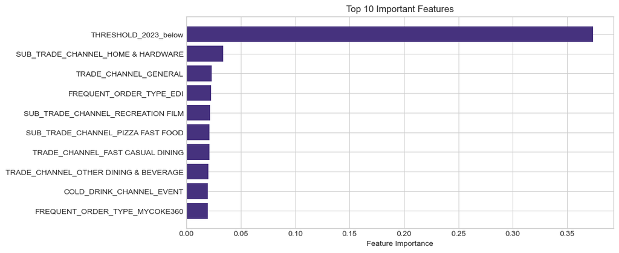

```python
# Extract feature importance
feature_importance = pd.DataFrame({
    'Feature': X_train.columns,
    'Importance': best_xgb.feature_importances_
}).sort_values(by='Importance', ascending=False)

# Plot feature importance
plt.figure(figsize=(10, 5))
plt.barh(feature_importance['Feature'][:10], feature_importance['Importance'][:10])
plt.gca().invert_yaxis()  # Flip highest importance to top
plt.xlabel("Feature Importance")
plt.title("Top 10 Important Features")
plt.show()
```

## Delivery Cost Optimization

```python
sccu_segmentation = file_path.copy()
```

```python
# Load the Data
file_path = 'sccu_data.csv'
sccu_segmentation = file_path

df = pd.read_csv(sccu_segmentation)
print("Data loaded. Shape:", df.shape)
print(df.head())
```

```
Data loaded. Shape: (30755, 37)
   Unnamed: 0  CUSTOMER_NUMBER FIRST_TRANSACTION_DATE LAST_TRANSACTION_DATE  \
0           1        500245678             2023-01-09            2024-11-20
1           2        500245685             2023-01-06            2024-08-16
2           3        500245686             2023-03-07            2024-12-17
3           4        500245687             2023-02-06            2024-10-28
4           5        500245689             2023-01-13            2024-12-26

   TRANS_DAYS  TRANS_COUNT  TRANS_COUNT_2023  TRANS_COUNT_2024  \
0         682           44                27                17
1         589           63                46                17
2         652            9                 5                 4
3         631           18                 9                 9
4         714           85                40                45

```

[output cut: 36 more lines]

```python
# Create modeling features and target
df['Total_Ordered_Cases'] = df['ANNUAL_VOLUME_CASES_2023']
df['Order_Frequency_2023'] = df['TRANS_COUNT_2023']
df['Percentage_Drop'] = df['PERCENT_CHANGE']
df['Threshold_2023'] = df['THRESHOLD_2023'].str.lower()

# Drop rows with missing values in relevant columns
model_df = df[['Total_Ordered_Cases', 'Order_Frequency_2023', 'Percentage_Drop', 'Threshold_2023']].dropna()

print("Filtered for non-null rows. Shape:", model_df.shape)
```

```
Filtered for non-null rows. Shape: (30618, 4)
```

```python
from sklearn.preprocessing import LabelEncoder

# Encode target variable
le = LabelEncoder()
model_df['Threshold_2023_encoded'] = le.fit_transform(model_df['Threshold_2023'])

# Define features and target
features = ['Total_Ordered_Cases', 'Order_Frequency_2023', 'Percentage_Drop']
X = model_df[features]
y = model_df['Threshold_2023_encoded']
```

```python
from sklearn.model_selection import train_test_split
import numpy as np
import pandas as pd

# Define features and target
X_train, X_test, y_train, y_test = train_test_split(X, y, stratify=y, test_size=0.2, random_state=42)

# Manual undersampling
train_df = X_train.copy()
train_df['target'] = y_train

majority = train_df[train_df['target'] == 0]
minority = train_df[train_df['target'] == 1]

# Balance the dataset by undersampling the majority class
minority_count = min(len(majority), len(minority))
majority_sampled = majority.sample(n=minority_count, random_state=42)
minority_sampled = minority.sample(n=minority_count, random_state=42)

balanced_df = pd.concat([majority_sampled, minority_sampled])

# Separate features and target from the balanced dataset
X_balanced = balanced_df[features]
y_balanced = balanced_df['target']

# Clean for infinity or large invalid values
X_balanced.replace([np.inf, -np.inf], np.nan, inplace=True)
X_test.replace([np.inf, -np.inf], np.nan, inplace=True)

# Drop rows with missing values (from balancing and cleaning)
X_balanced.dropna(inplace=True)
y_balanced = y_balanced.loc[X_balanced.index]

X_test.dropna(inplace=True)
y_test = y_test.loc[X_test.index]

# Final check
print("Balanced and cleaned dataset.")
print("Balanced class counts:\n", y_balanced.value_counts())
```

```
Balanced and cleaned dataset.
Balanced class counts:
 target
0    6338
1    5161
Name: count, dtype: int64
```

## Logistic Regression Model Training

```
📋 Classification Report:

              precision    recall  f1-score   support

       above       0.74      0.87      0.80      1585
       below       0.94      0.87      0.90      3718

    accuracy                           0.87      5303
   macro avg       0.84      0.87      0.85      5303
weighted avg       0.88      0.87      0.87      5303
```

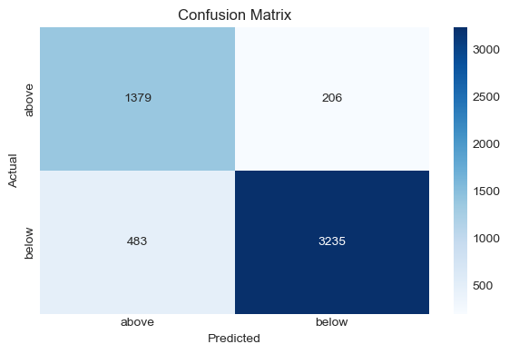

```python
from sklearn.linear_model import LogisticRegression
from sklearn.metrics import classification_report, confusion_matrix


# Train Logistic Regression Model
lr = LogisticRegression(max_iter=1000)
lr.fit(X_balanced, y_balanced)
#Predict and Evaluate
y_pred = lr.predict(X_test)
report = classification_report(y_test, y_pred, target_names=le.classes_)
conf_matrix = confusion_matrix(y_test, y_pred)

print("\n📋 Classification Report:\n")
print(classification_report(y_test, y_pred, target_names=le.classes_))

# Confusion Matrix
conf_matrix = confusion_matrix(y_test, y_pred)
plt.figure(figsize=(6, 4))
sns.heatmap(conf_matrix, annot=True, fmt='d', cmap='Blues',
            xticklabels=le.classes_, yticklabels=le.classes_)
plt.title("Confusion Matrix")
plt.xlabel("Predicted")
plt.ylabel("Actual")
plt.tight_layout()
plt.show()
```

Model used is Logistic Regression where accuracy is 87%. Precision above is 0.74, below is 0.94. Recall above is 0.87 , below is 0.87. Model performs strongly on both classes, especially the majority 'below' class. Manual under sampling helped balance recall across classes.

## Number of Customers who Improved from Below to Above

```python
# Count Customers Who Improved from 'below' to 'above'
# Normalize casing for consistency
df['THRESHOLD_2023'] = df['THRESHOLD_2023'].str.lower()
df['THRESHOLD_2024'] = df['THRESHOLD_2024'].str.lower()

# Identify improved customers
improved_customers = df[
    (df['THRESHOLD_2023'] == 'below') &
    (df['THRESHOLD_2024'] == 'above')
]

# Output the count
num_improved = improved_customers.shape[0]
print(f"\n Number of customers who improved from 'below' to 'above': {num_improved}")
```

```
 Number of customers who improved from 'below' to 'above': 1268
```

## Cluster Improved Customers by ZIP Code and Volume

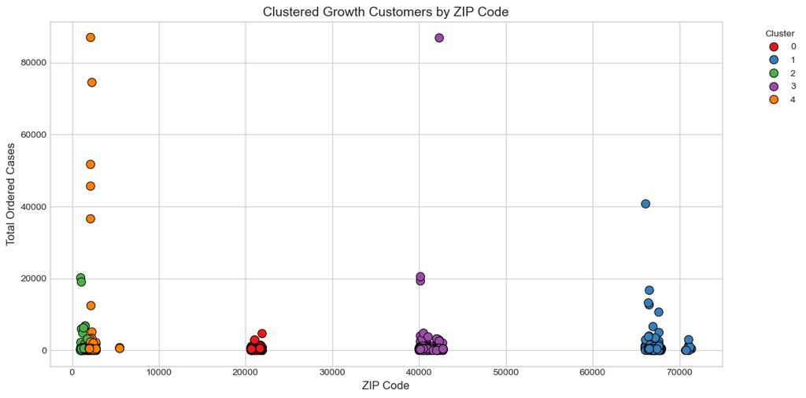

```python
#Cluster Improved Customers by ZIP Code and Volume

import matplotlib.pyplot as plt
import seaborn as sns
from sklearn.cluster import KMeans

# Prepare improved customers data again if needed
transitioned_customers = df[
    (df['THRESHOLD_2023'] == 'below') &
    (df['THRESHOLD_2024'] == 'above')
]

# Select ZIP and volume columns
growth_customers = transitioned_customers[["ZIP_CODE", "ANNUAL_VOLUME_CASES_2024"]].dropna()
growth_customers = growth_customers.rename(columns={"ANNUAL_VOLUME_CASES_2024": "Total_Ordered_Cases"})

# Ensure ZIP_CODE is numeric
growth_customers = growth_customers[growth_customers['ZIP_CODE'].apply(lambda x: str(x).isdigit())]
growth_customers["ZIP_CODE"] = growth_customers["ZIP_CODE"].astype(int)

# Perform K-Means clustering
kmeans = KMeans(n_clusters=5, random_state=42)
growth_customers["Cluster"] = kmeans.fit_predict(growth_customers[["ZIP_CODE"]])

# Plot the clusters
plt.figure(figsize=(12, 6))
sns.scatterplot(
    data=growth_customers,
    x="ZIP_CODE",
    y="Total_Ordered_Cases",
    hue="Cluster",
    palette="Set1",
    s=80,
    edgecolor='black'
)

plt.title("Clustered Growth Customers by ZIP Code", fontsize=14)
plt.xlabel("ZIP Code", fontsize=12)
plt.ylabel("Total Ordered Cases", fontsize=12)
plt.legend(title="Cluster", bbox_to_anchor=(1.05, 1), loc='upper left')
plt.grid(True)
plt.tight_layout()
plt.show()
```

X-axis: ZIP Code, Y-axis: Total Ordered Cases in 2024 (i.e., volume). Color: Represents the assigned Cluster (0–4) from K-Means. Each point = 1 customer who improved from below to above threshold Customers were grouped solely by ZIP Code whic h creates geographic clusters Largest-volume customers are spread across clusters which suggests volume alone isn’t geographically concentrated.

## Cluster Improved Customers data using Ordered Gallon

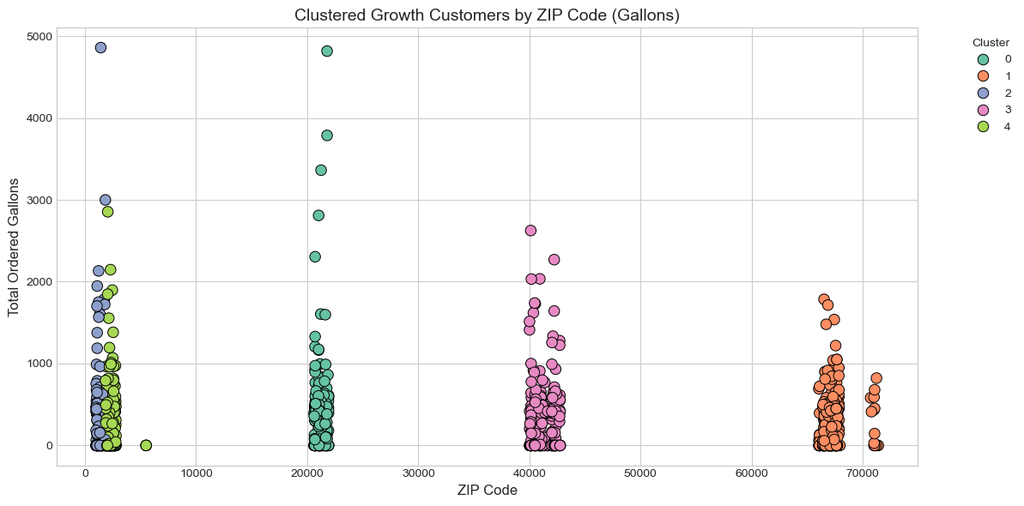

```python
# Prepare improved customers data again( Used Ordered Gallons )
transitioned_customers = df[
    (df['THRESHOLD_2023'] == 'below') &
    (df['THRESHOLD_2024'] == 'above')
]

# Select ZIP and GALLON volume
growth_customers = transitioned_customers[["ZIP_CODE", "ANNUAL_VOLUME_GALLON_2024"]].dropna()
growth_customers = growth_customers.rename(columns={"ANNUAL_VOLUME_GALLON_2024": "Total_Ordered_Gallons"})

# Ensure ZIP_CODE is numeric
growth_customers = growth_customers[growth_customers['ZIP_CODE'].apply(lambda x: str(x).isdigit())]
growth_customers["ZIP_CODE"] = growth_customers["ZIP_CODE"].astype(int)

# KMeans clustering
from sklearn.cluster import KMeans
kmeans = KMeans(n_clusters=5, random_state=42)
growth_customers["Cluster"] = kmeans.fit_predict(growth_customers[["ZIP_CODE"]])

# Plot
import matplotlib.pyplot as plt
import seaborn as sns

plt.figure(figsize=(12, 6))
sns.scatterplot(
    data=growth_customers,
    x="ZIP_CODE",
    y="Total_Ordered_Gallons",
    hue="Cluster",
    palette="Set2",
    s=80,
    edgecolor='black'
)
plt.title("Clustered Growth Customers by ZIP Code (Gallons)", fontsize=14)
plt.xlabel("ZIP Code", fontsize=12)
plt.ylabel("Total Ordered Gallons", fontsize=12)
plt.legend(title="Cluster", bbox_to_anchor=(1.05, 1), loc='upper left')
plt.grid(True)
plt.tight_layout()
plt.show()
```

This gallon-based view might show new patterns not obvious from case count alone — e.g., ZIPs with small case counts but high gallon volume, possibly due to large-batch liquid orders.